R version used: 4.5.1

## Prepare data for Analysis

Import gene expression data and convert to a dataframe

```r
# To install METAFlux
# devtools::install_github('KChen-lab/METAFlux')
library(METAFlux)
library(readxl)

# Returns a tibble, does not support row names
GSC_culture_expression <- read_excel("C:/research/GBM_cultures_only_gene_expression_matrix.xlsx")
# Convert to dataframe and set the first column as rownames
GSC_culture_expression <- as.data.frame(GSC_culture_expression)
rownames(GSC_culture_expression) <- GSC_culture_expression[[1]]
GSC_culture_expression[[1]] <- NULL

head(GSC_culture_expression)
```

```
##                BT41_L   BT48_L   BT50_L   BT53_L   BT67_L   BT69_L   BT73_L
## DDX11L1      1.719338 2.777221 1.697442 1.719338 1.697442 1.697442 1.719338
## WASH7P       8.374704 8.050898 7.448546 7.829159 7.963597 8.628875 8.319725
## LOC729737    4.139061 4.056114 2.483791 3.230338 2.156779 3.453151 2.716000
## FAM138D      1.712674 1.712674 1.731367 1.712674 1.731367 1.731367 1.712674
## LOC101928626 1.723233 1.723233 2.832425 1.723233 1.751513 1.751513 1.723233
## MIR6723      1.750962 1.750962 1.872075 1.750962 1.872075 3.031949 1.750962
##                BT75_L   BT84_L   BT89_L   BT94_L  BT100_L  BT106_L  BT108_L
## DDX11L1      1.719338 1.719338 2.681513 1.697442 2.150719 1.719338 1.719338
## WASH7P       8.451641 9.911759 8.361340 7.768512 8.408399 7.947212 8.155917
## LOC729737    4.492299 5.670715 3.567389 3.240305 5.441825 3.242693 3.248350
## FAM138D      1.712674 1.712674 1.731367 1.731367 1.687276 1.712674 1.712674
## LOC101928626 1.723233 1.723233 1.751513 1.751513 1.674886 1.723233 1.723233
## MIR6723      1.750962 1.750962 1.872075 1.872075 1.633417 1.750962 1.750962
##               BT119_L  BT126_L  BT134_L  BT140_L  BT143_L  BT147_L  BT169_L
## DDX11L1      1.719338 1.719338 1.719338 1.719338 1.719338 1.719338 2.659712
## WASH7P       8.420082 8.971684 7.876995 8.742331 7.798349 7.435886 7.580916
## LOC729737    4.249875 5.834431 5.607239 4.319629 3.091960 4.138416 7.788721
## FAM138D      1.712674 1.712674 1.712674 1.712674 1.712674 1.712674 1.731367
## LOC101928626 1.723233 1.723233 1.723233 1.723233 1.723233 1.723233 1.751513
## MIR6723      1.750962 1.750962 1.750962 1.750962 1.750962 1.750962 1.872075
##               BT189_L  BT208_L  BT238_L  BT241_L  BT248_L  BT284_L  BT301_L
## DDX11L1      1.709471 1.719338 1.697442 1.719338 1.709471 1.709471 1.697442
## WASH7P       8.108190 8.180192 8.454209 8.524576 8.606059 7.964643 9.107078
## LOC729737    3.758578 2.757006 4.912520 2.641493 5.009836 3.612270 4.273927
## FAM138D      1.687276 1.712674 1.731367 1.712674 1.687276 1.687276 1.731367
## LOC101928626 1.674886 1.723233 1.751513 1.723233 1.674886 1.674886 1.751513
## MIR6723      1.633417 1.750962 1.872075 1.750962 1.633417 1.633417 1.872075
##               BT338_L  BT426_L  BT428_L  BT429_L  BT465_L  BT466_L  BT467_L
## DDX11L1      1.713347 1.709471 1.709471 1.719338 1.713347 1.713347 1.713347
## WASH7P       8.636107 7.870805 8.993282 8.382997 9.165014 8.852452 8.963739
## LOC729737    7.038587 4.015731 5.093498 4.879450 4.547314 3.951889 8.650087
## FAM138D      1.691385 1.687276 1.687276 1.712674 1.691385 1.691385 1.691385
## LOC101928626 1.692277 1.674886 1.674886 1.723233 1.692277 1.692277 1.692277
## MIR6723      1.712543 1.633417 1.633417 1.750962 2.543004 1.712543 1.712543
##               BT468_L   G361_L   G411_L   G489_L   G498_L   G523_L   G549_L
## DDX11L1      1.713347 1.652693 2.415696 1.652693 1.652693 2.684551 1.697442
## WASH7P       9.041747 8.380148 7.654341 8.619598 8.412746 8.397148 8.195249
## LOC729737    3.797961 4.247654 5.699900 2.676273 2.676273 2.339967 3.176777
## FAM138D      1.691385 1.700812 1.700812 1.700812 1.700812 1.731367 1.731367
```

[output cut: 36 more lines]

```
## MIR6723      1.633417 1.633417 1.742055 2.016560 1.633417 1.633417 1.633417
##                G895_L   G900_L   G913_L   G914_L   G929_L   G931_L   G933_L
## DDX11L1      1.709471 1.713347 1.713347 1.713347 1.713347 1.713347 1.713347
## WASH7P       7.698591 7.942502 7.880315 8.256605 8.057031 8.617732 7.284431
## LOC729737    4.712062 6.318824 5.643448 3.017721 3.357924 3.034619 1.786736
## FAM138D      1.687276 1.691385 1.691385 1.691385 1.691385 1.691385 1.691385
## LOC101928626 1.674886 1.692277 1.692277 1.692277 1.692277 1.692277 1.692277
## MIR6723      1.633417 1.712543 1.712543 1.712543 1.712543 1.712543 1.712543
##                G945_L   G946_L   G957_L   G958_L
## DDX11L1      1.713347 1.713347 2.663052 1.713347
## WASH7P       7.901437 8.497871 7.770726 7.985315
## LOC729737    5.411174 4.508426 6.747654 2.754523
## FAM138D      1.691385 1.691385 1.691385 1.691385
## LOC101928626 1.692277 1.692277 1.692277 1.692277
## MIR6723      1.712543 1.712543 1.712543 1.712543
```

## Calculate Flux

Calculate the MRAS (Metabolic Reaction Activity Score)

```r
# METAFlux only accepts positive values, replace negative values with a small positive number
# Get positions (row/column) of non-positive values
# which(GSC_culture_expression <= 0, arr.ind = TRUE)
GSC_culture_expression[GSC_culture_expression < 0] <- 1e-5

GSC_scores <- calculate_reaction_score(GSC_culture_expression)
```

```
## 94.897% metabolic related genes were found......
```

```
## Computing metabolic reaction activity scores......
```

```
## Preparing for score matrix......
```

```
## Metabolic reaction activity scores successfully calculated
```

Calculate flux

```r
#Calculate flux for cell line data
GSC_flux <- compute_flux(mras=GSC_scores,medium = cell_medium)
```

```
## Setting up for optimization.....
```

```
## Computing bulk RNA-seq flux.....
```

[output not shown]

## Assign Subtype Labels to GSC Lines

Using GSVA, identify which cell lines are developmental and which are IR

```r
library(GSVA)
# Import gene signatures for developmental and injury response subtypes
signatures <- read_excel("C:/research/43018_2020_154_MOESM9_ESM (8).xlsx")
signatures_df <- as.data.frame(signatures)

# head(signatures_df, n = 10)

# Filter genes in the Developmental group
developmental_genes <- signatures_df$Gene[signatures_df$Group == "Developmental"]
length(developmental_genes)
```

```
## [1] 3968
```

```r
# Filter genes in the Injury Response group
injury_response_genes <- signatures_df$Gene[signatures_df$Group == "Injury_Response"]
length(injury_response_genes)
```

```
## [1] 4399
```

```r
combined_signatures <- list(
  DEV_gs = developmental_genes,
  IR_gs = injury_response_genes
)
# head(combined_signatures)

# class(injury_response_genes)
# str(injury_response_genes)

expr_matrix <- as.matrix(GSC_culture_expression)
# mode(expr_matrix)

param <- gsvaParam(expr_matrix, combined_signatures)
gsva_results <- gsva(param)
```

```
## ℹ GSVA version 2.2.0
```

```
## ℹ Calculating GSVA ranks
```

```
## ℹ kcdf='auto' (default)
```

```
## ℹ GSVA dense (classical) algorithm
```

```
## ℹ Row-wise ECDF estimation with Gaussian kernels
```

[output not shown]

```r
# write.csv(gsva_results, "C:/research/20250809_cellline_gsva_results.csv", row.names = TRUE)
```

Make metadata table based on GSVA results and reformat for PCA coloring Looking at the GSVA scores, if dev > IR –> dev, else if dev < IR –> IR

```r
gsva_results_t <- t(gsva_results)
gsva_results_t <- as.data.frame(gsva_results_t)

gsva_results_t$subtype <- ifelse(gsva_results_t$DEV_gs > gsva_results_t$IR_gs, "developmental", "injury_response")
```

## Make PCA plot

```r
# Transpose the flux matrix
GSC_flux_t <- t(GSC_flux)
```

Resolved error from running prcomp

```r
# Got an error: cannot rescale a constant/zero column to unit variance
# To resolve, identify columns that are entirely zero
all_zero_reactions <- names(which(colSums(GSC_flux_t) == 0))
length(all_zero_reactions)
```

```
## [1] 99
```

```r
# Print column given reaction name
# Example: reaction of interest
reaction_name <- "HMR_0024"

# Extract the column
reaction_flux <- GSC_flux_t[, reaction_name]

# Print it
print(reaction_flux)
```

```
##  BT41_L  BT48_L  BT50_L  BT53_L  BT67_L  BT69_L  BT73_L  BT75_L  BT84_L  BT89_L
##       0       0       0       0       0       0       0       0       0       0
##  BT94_L BT100_L BT106_L BT108_L BT119_L BT126_L BT134_L BT140_L BT143_L BT147_L
##       0       0       0       0       0       0       0       0       0       0
## BT169_L BT189_L BT208_L BT238_L BT241_L BT248_L BT284_L BT301_L BT338_L BT426_L
##       0       0       0       0       0       0       0       0       0       0
## BT428_L BT429_L BT465_L BT466_L BT467_L BT468_L  G361_L  G411_L  G489_L  G498_L
##       0       0       0       0       0       0       0       0       0       0
##  G523_L  G549_L  G551_L  G561_L  G564_L  G566_L  G567_L  G571_L  G577_L  G583_L
##       0       0       0       0       0       0       0       0       0       0
##  G584_L  G594_L  G613_L  G620_L  G637_L  G648_L  G683_L  G691_L  G702_L  G705_L
##       0       0       0       0       0       0       0       0       0       0
##  G706_L  G719_L  G729_L  G744_L  G789_L  G797_L  G799_L  G800_L  G809_L  G811_L
##       0       0       0       0       0       0       0       0       0       0
##  G823_L  G828_L  G837_L  G851_L  G861_L  G876_L  G885_L  G895_L  G900_L  G913_L
##       0       0       0       0       0       0       0       0       0       0
##  G914_L  G929_L  G931_L  G933_L  G945_L  G946_L  G957_L  G958_L
##       0       0       0       0       0       0       0       0
```

```r
# Remove columns that are all zero
GSC_flux_t_nonzero <- GSC_flux_t[, colSums(GSC_flux_t) != 0]

# Check dimensions before and after
dim(GSC_flux_t)
```

```
## [1]    88 13082
```

```r
dim(GSC_flux_t_nonzero)
```

```
## [1]    88 12983
```

```r
# Create a PCA plot
pca <- prcomp(GSC_flux_t_nonzero, scale. = TRUE)
```

Making the plot

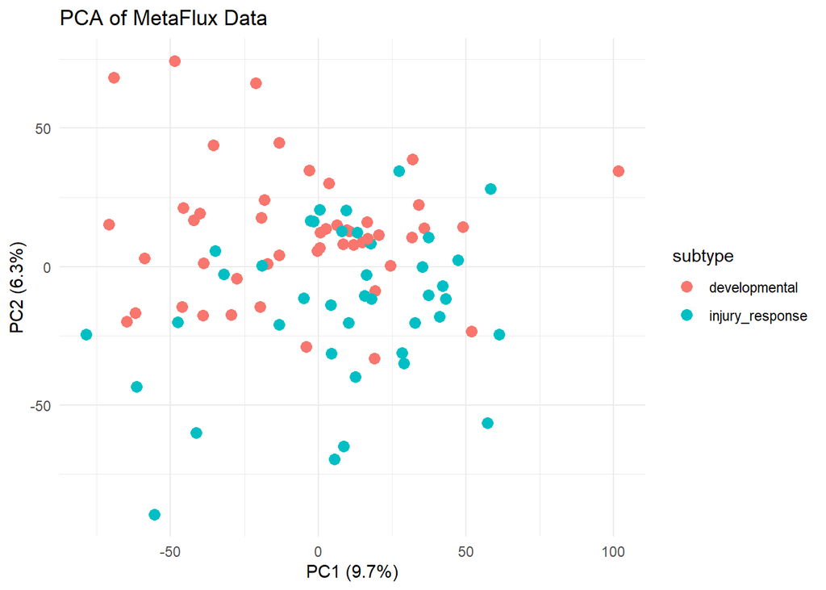

```r
library(ggplot2)

# Convert to a data frame for ggplot
pca_df <- data.frame(
  Sample = rownames(pca$x),
  PC1 = pca$x[,1],
  PC2 = pca$x[,2]
)

merged_df <- merge(pca_df, gsva_results_t, by = "row.names", all.x = TRUE)

ggplot(merged_df, aes(x = PC1, y = PC2, color = subtype)) +
  geom_point(size = 3) +
  theme_minimal() +
  labs(title = "PCA of MetaFlux Data",
       x = paste0("PC1 (", round(summary(pca)$importance[2,1]*100,1), "%)"),
       y = paste0("PC2 (", round(summary(pca)$importance[2,2]*100,1), "%)"))
```

## Make Boxplots To compare fluxes between developmental and IR subtypes for specific reactions

```r
# Load the genome-scale metabolic model
data("human_gem")
data("nutrient_lookup_files")

# Identify reactions with tryptophan in the equation
# trp_matches <- grepl("tryptophan", human_gem$EQUATION, ignore.case = TRUE)
# trp_gem <- human_gem[trp_matches, ]
```

For a single reaction

```r
# Compare tryptophan import, reaction ID: HMR_5317
HMR_5317 <- GSC_flux_t[, "HMR_5317"]
trp_import <- merge(as.data.frame(HMR_5317), gsva_results_t, by = "row.names")

# Count number of samples in each group
table(trp_import$subtype)
```

```
##
##   developmental injury_response
##              48              40
```

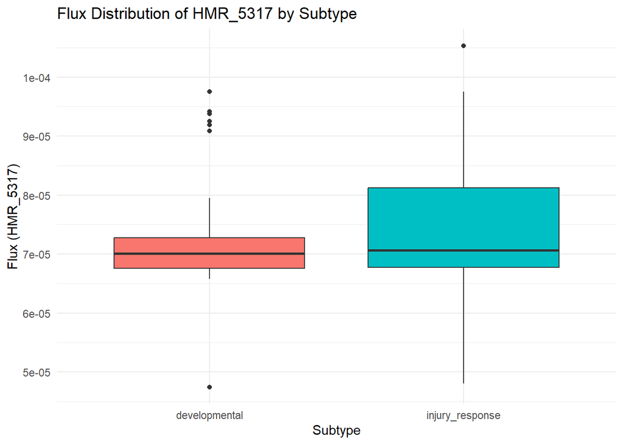

```r
ggplot(trp_import, aes(x = subtype, y = HMR_5317, fill = subtype)) +
  geom_boxplot() +
  theme_minimal() +
  labs(
    title = "Flux Distribution of HMR_5317 by Subtype",
    x = "Subtype",
    y = "Flux (HMR_5317)"
  ) +
  theme(legend.position = "none")  # remove legend if fill duplicates x-axis
```

```r
t.test(HMR_5317 ~ subtype, data = trp_import)
```

```
##
##  Welch Two Sample t-test
##
## data:  HMR_5317 by subtype
## t = -1.4935, df = 71.258, p-value = 0.1397
## alternative hypothesis: true difference in means between group developmental and group injury_response is not equal to 0
## 95 percent confidence interval:
##  -8.217186e-06  1.178809e-06
## sample estimates:
##   mean in group developmental mean in group injury_response
##                  7.229848e-05                  7.581766e-05
```

Function that plots given reaction ID

[figure not shown]

```
##
##  Welch Two Sample t-test
##
## data:  reaction_df by subtype
## t = 8.089, df = 55.798, p-value = 5.659e-11
## alternative hypothesis: true difference in means between group developmental and group injury_response is not equal to 0
## 95 percent confidence interval:
##  1.304769e-05 2.163838e-05
## sample estimates:
##   mean in group developmental mean in group injury_response
##                  2.070134e-05                  3.358303e-06
```

```r
# Function that makes boxplots for the flux given the reaction ID
make_boxplots_for_reaction <- function(reaction_name){
  reaction_df <- GSC_flux_t[, reaction_name]
  merged_reaction_df <- merge(as.data.frame(reaction_df), gsva_results_t, by = "row.names")

  boxplot <- ggplot(merged_reaction_df, aes(x = subtype, y = reaction_df, fill = subtype)) +
  geom_boxplot() +
  theme_minimal() +
  labs(
    title = "Flux Distribution of HMR_5317 by Subtype",
    x = "Subtype",
    y = paste("Flux", reaction_name)
  ) +
  theme(legend.position = "none")  # remove legend if fill duplicates x-axis
  print(boxplot)

  ttest_result <- t.test(reaction_df ~ subtype, data = merged_reaction_df)
  print(ttest_result)
}

make_boxplots_for_reaction("HMR_5651")
```

## Make Volcano Plot

Calculate mean flux difference and p-value across all reactions FDR calculated as well

```r
# Convert flux matrix to dataframe
GSC_flux_t_nonzero_df <- as.data.frame(GSC_flux_t_nonzero)

# Merge gsva labels GSC flux dataframe
merged_df_with_labels <- merge(gsva_results_t, GSC_flux_t_nonzero_df, by = "row.names")

rownames(merged_df_with_labels) <- merged_df_with_labels$Row.names
merged_df_with_labels <- merged_df_with_labels[, -c(1, 2, 3)]
```

```r
# Loop over all reaction columns except subtype
results <- sapply(
  names(merged_df_with_labels)[!names(merged_df_with_labels) %in% "subtype"],
  function(reaction) {
    t.test(merged_df_with_labels[[reaction]] ~ merged_df_with_labels$subtype)$p.value
  }
)

# Make into dataframe
results_df <- data.frame(
  Reaction = names(results),
  P_value = results
)

# Adjust p-values
results_df$adj_P_value <- p.adjust(results_df$P_value, method = "fdr")

# Sort by smallest p-value
results_df <- results_df[order(results_df$P_value), ]
head(results_df)
```

```
##          Reaction      P_value  adj_P_value
## INSt2       INSt2 3.727723e-15 4.839702e-11
## HMR_6357 HMR_6357 8.002847e-15 5.195048e-11
## HMR_5042 HMR_5042 6.093393e-14 2.637017e-10
## HMR_5669 HMR_5669 1.463094e-13 4.748838e-10
## HMR_4016 HMR_4016 1.092838e-12 2.837662e-09
## HMR_6359 HMR_6359 2.079696e-12 4.500116e-09
```

```r
# Calculate mean difference (Developmental - IR) for each reaction
mean_diff <- sapply(
  names(merged_df_with_labels)[!names(merged_df_with_labels) %in% "subtype"],
  function(reaction) {
    mean(merged_df_with_labels[merged_df_with_labels$subtype == "developmental", reaction], na.rm = TRUE) -
    mean(merged_df_with_labels[merged_df_with_labels$subtype == "injury_response", reaction], na.rm = TRUE)
  }
)

results_df$mean_diff <- mean_diff
```

```r
# Make a separate df containing only significant results
significant_df <- results_df[results_df$adj_P_value < 0.01, ]

# Merge significant hits with human_gem to easily identify reactions
significant_df <- merge(significant_df, human_gem, by.x = "Reaction", by.y = "ID")
```

Making the volcano plot

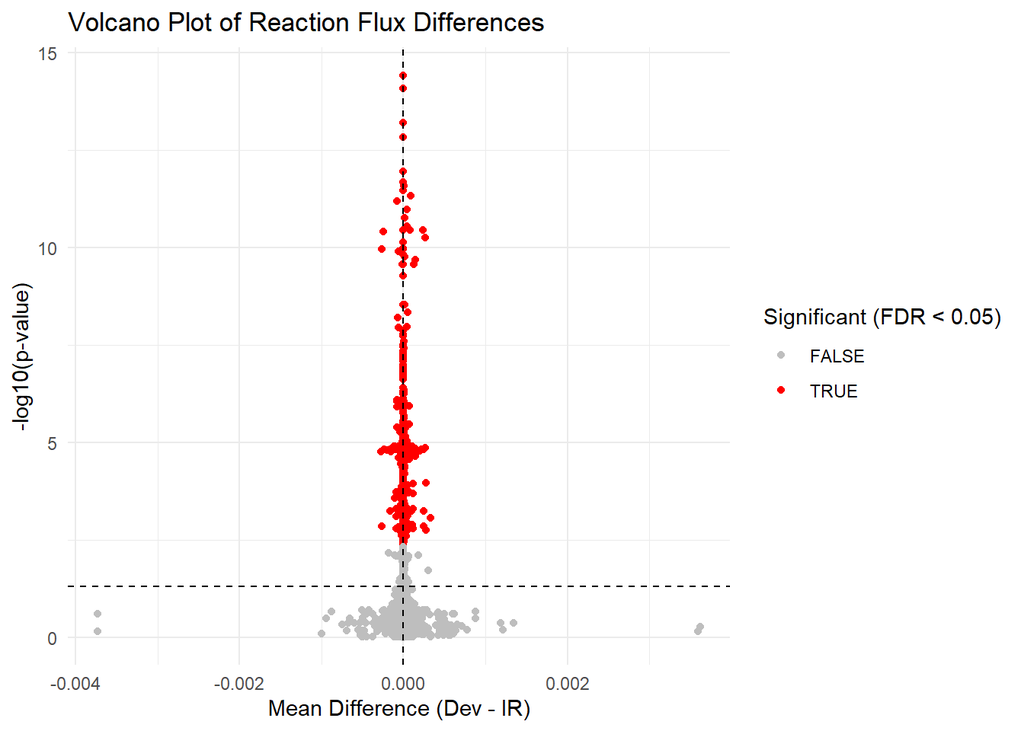

```r
ggplot(results_df, aes(x = mean_diff, y = -log10(P_value))) +
  geom_point(aes(color = adj_P_value < 0.05)) +  # Color significant points
  scale_color_manual(values = c("grey", "red")) +
  theme_minimal() +
  labs(
    title = "Volcano Plot of Reaction Flux Differences",
    x = "Mean Difference (Dev - IR)",
    y = "-log10(p-value)",
    color = "Significant (FDR < 0.05)"
  ) +
  geom_vline(xintercept = 0, linetype = "dashed") +  # Reference line
  geom_hline(yintercept = -log10(0.05), linetype = "dashed")  # p=0.05 threshold
```

```r
  coord_cartesian(xlim = c(-0.001, 0.001))  # Zoom into range
```

[output not shown]

Volcano plot with top hits labeled

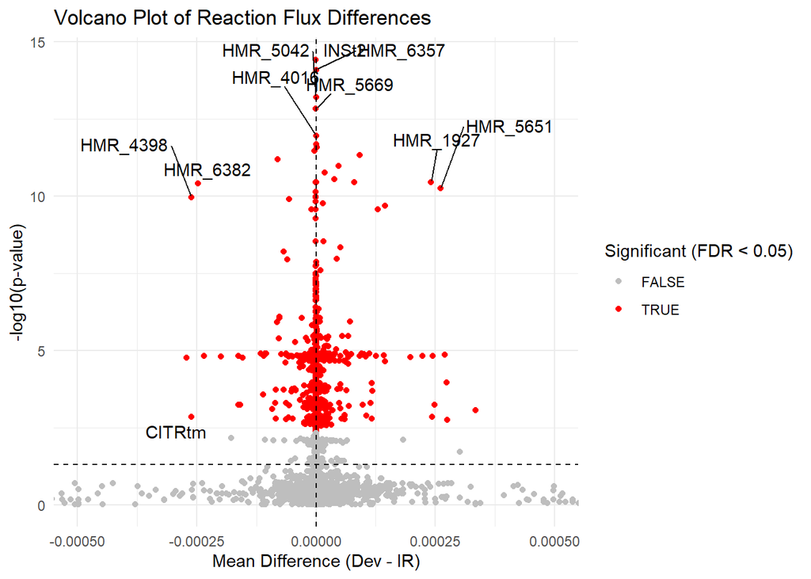

```r
library(ggrepel)

# Assume results_df has rownames = reaction names
results_df$Reaction <- rownames(results_df)

ggplot(results_df, aes(x = mean_diff, y = -log10(P_value))) +
  geom_point(aes(color = adj_P_value < 0.05)) +
  scale_color_manual(values = c("grey", "red")) +
  theme_minimal() +
  labs(
    title = "Volcano Plot of Reaction Flux Differences",
    x = "Mean Difference (Dev - IR)",
    y = "-log10(p-value)",
    color = "Significant (FDR < 0.05)"
  ) +
  geom_vline(xintercept = 0, linetype = "dashed") +
  geom_hline(yintercept = -log10(0.05), linetype = "dashed") +
  coord_cartesian(xlim = c(-0.0005, 0.0005)) +
  geom_text_repel(aes(label = Reaction),
                  data = subset(results_df, adj_P_value < 0.05))  # only label significant points
```

## Make Pie Charts

Made a pie chart using the dataframe containing only significant hits, summarized the most frequently appearing top 5 subsystem labels in a pie chart. Compared this to a pie chart made similarly with all of the reactions in the human1 GEM model. Perhaps most striking is the increased percentage of reactions related to peptide metabolism. It represents only 1.8% of the entire set of reactions but 19.1% of the reactions with differential flux between developmental and IR subtypes

```r
# Count reactions per subsystem
pie_counts <- table(human_gem$SUBSYSTEM)

# Sort descending
pie_counts <- sort(pie_counts, decreasing = TRUE)

# print(pie_counts)
print(pie_counts["Peptide metabolism"]/sum(pie_counts))
```

```
## Peptide metabolism
##          0.0184987
```

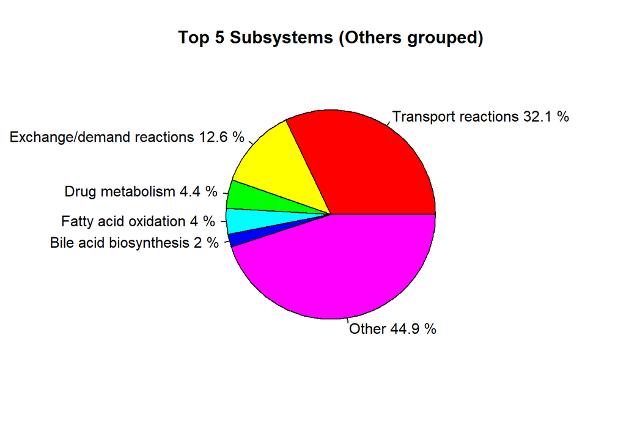

```r
# Keep top 5, sum the rest as "Other"
top_n <- 5
if(length(pie_counts) > top_n){
  top_counts <- pie_counts[1:top_n]
  other_count <- sum(pie_counts[(top_n + 1):length(pie_counts)])
  pie_counts <- c(top_counts, Other = other_count)
}

# Calculate percentages
labels <- paste(names(pie_counts), round(100 * pie_counts / sum(pie_counts), 1), "%")

# Create pie chart
pie(pie_counts, labels = labels, main = "Top 5 Subsystems (Others grouped)", col = rainbow(length(pie_counts)))
```

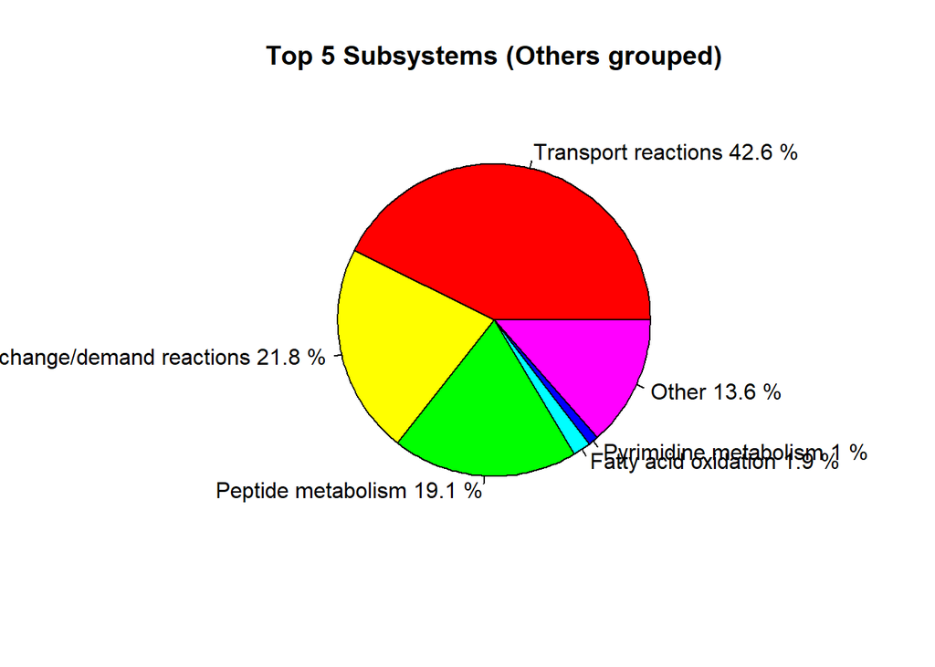

```r
# Count reactions per subsystem
pie_counts_sig <- table(significant_df$SUBSYSTEM)

# Sort descending
pie_counts_sig <- sort(pie_counts_sig, decreasing = TRUE)

# Keep top 5, sum the rest as "Other"
top_n_sig <- 5
if(length(pie_counts_sig) > top_n_sig){
  top_counts <- pie_counts_sig[1:top_n_sig]
  other_count <- sum(pie_counts_sig[(top_n_sig + 1):length(pie_counts_sig)])
  pie_counts_sig <- c(top_counts, Other = other_count)
}

# Calculate percentages
labels <- paste(names(pie_counts_sig), round(100 * pie_counts_sig / sum(pie_counts_sig), 1), "%")

# Create pie chart
pie(pie_counts_sig, labels = labels, main = "Top 5 Subsystems (Others grouped)", col = rainbow(length(pie_counts_sig)))
```